# Grundlagen Statistik

In dieser Lektion wollen wir einige grundlegende statitische Größen wiederholen bzw. einführen. Das meiste dürfte bereits bekannt sein. Wir wollen aber neben dem theoretischen Grundlagen auch zeigen, wie wir diese Statistiken in der Programmiersprache Python berechnen können.

Wir greifen hierfür auf den Datensatz *heights* zurück. Der Datensatz steht auf GitHub in einem öffentlichen Repository zur Verfügung. Das folgende Python-Programm verwendet für das Laden des Datensatzes die Methode *read_csv* aus dem Package *Pandas*. Nach dem Laden des Datensatzes geben wir die ersten 5 Zeilen aus.

```python
import pandas as pd
url = "https://raw.githubusercontent.com/troescherw/datasets/master/heights.csv"
daten = pd.read_csv(url, delimiter=";")
daten.head()
```

|  | sex | height |
| --- | --- | --- |
| 0 | Male | 75.0 |
| 1 | Male | 70.0 |
| 2 | Male | 68.0 |
| 3 | Male | 74.0 |
| 4 | Male | 61.0 |

*heights* besteht aus zwei Spalten (sog. Features):

- sex: Dem Geschlecht der untersuchten Person
- height: Die Größe in inches

Basierend auf diesen Daten wollen wir nun einige häufig benutzte Statistiken erstellen. Diese wollen wir einerseits aufgrund der mathematischen Definition berechnen bzw. etwaig bereits in Python vorhandene Funktionen nutzen.

## Maximum und Minimum

Zuerst geben wir die maximale und minimale Größe aus. Hierfür nutzen wir die Pandas-Funktionen *min* bzw. *max*. Damit können wir auch die Spannweite berechnen:

```python
print("Minimalwert:", daten.height.min())
print("Maximalwert:", daten.height.max())
print("Spannweite: ",  daten.height.max()-daten.height.min())
```

```
Minimalwert: 50.0
Maximalwert: 82.6771653543307
Spannweite:  32.6771653543307
```

# Mittelwert

Der Mittelwert ist der Quotient aus der Summe der Einzelwerte und der Anzahl der Werte:

$ \bar{x} = \frac{1}{n}\sum _{i=1}^{n}x_{i} $

Wir verwenden hierfür die Funktion *mean*, um den Mittelwert aller Körpergrößen zu ermitteln:

```python
daten.height.mean()
```

```
68.32301331818971
```

Wollen wir den Mittelwert der Körpergrößen der Männer ermitteln, müssen wir zuerst die entsprechenden Werte selektieren:

```python
daten[daten.sex=="Male"].height.mean()
```

```
69.31475494143558
```

**Übung:** Ermitteln Sie die durchschnittliche Körpergröße der Frauen!

```python
# Hier den Code eingeben:
```

## Varianz und Standardabweichung (Stichprobe)

De Varianz und die Standardabweichung sind Kennzahlen für die Streuung der Daten. Alle diese Kennzahlen werden umso größer, je größer die Streuung in einer Datenreihe ist. Sie sind wie folgt definiert:

$ s^2 = \frac{1}{n-1}\sum _{i=1}^{n}(x_{i} - \bar{x})^2$

Die Standardabweichung ist die Wurzel der Varianz:

$ s = \sqrt{\frac{1}{n-1}\sum _{i=1}^{n}(x_{i} - \bar{x})^2} $

Wir teilen hier jeweis durch (n-1), da wir meist nicht die Daten der Grundgesamtheit zur Verfügung haben. In unserem Beispiel müssten wir die Größen **aller** Männer und Frauen haben! Unser Datensatz ist aber nur eine Stichprobe, sodass wir die Standardabweichung bzw. Varianz nur schätzen können. Meist wird die Standardabweichung der Stichprobe mit einem s bezeichnet, für die Grundgesamtheit mit einem $\sigma$, die Varianz analog mit $s^2$ mbzw. $\sigma^2$

```python
print("Standardabweichung: " , daten.height.std())
```

```
Standardabweichung:  4.078616969642443
```

```python
print("Varianz: " , daten.height.var())
```

```
Varianz:  16.63511638505531
```

## Verteilungen

### Binomialverteilung

Merkmale:

- Typ der Verteilung: Diskret
- Merkmal: Ziehen mit Zurücklegen
- Klassische Beispiele: Würfeln, Münzwurf

Definition: $ B(k\mid p,n)=\begin{cases} \binom nk p^k (1-p)^{n-k} &\text{falls} \quad k\in\left\{0,1,\dots,n\right\}\\ 0 & \text{sonst.}\end{cases} $

**Beispiel 1:** Wie hoch ist die Wahrscheinlichkeit, dass beim 10-maligen Würfeln exakt 3 mal eine 6 gewürfelt wird?

Gegeben:

- n = 10
- k = 3
- p = 1/6

\begin{eqnarray*} B(k \mid p,n) &=& \binom nk p^k (1-p)^{n-k} \\ &=& {10\choose 3} \cdot \left( \frac{1}{6}\right)^{3} \cdot \left(\frac{5}{6}\right)^{7} \\ &=& \frac{10!}{(10-3)! \cdot 3!} \cdot \left( \frac{1}{6}\right)^{3} \cdot \left(\frac{5}{6}\right)^{7} \\ &=& \underline{0,155} \end{eqnarray*}

Berechnung mit Hilfe der Funktion *pmf* aus dem Package *binom*:

```python
from scipy.stats import binom
binom.pmf(3, 10, 1/6)
```

```
0.15504535957425197
```

Wir erstellen mit Hilfe von Matplotlib ein Diagramm, das die Wahrscheinlichkeiten für oben angegebenes Beispiel zeigt: Wahrscheinlichkeiten beim 10-maligen Würfeln für 0, 1, 2, ... 10 mal die 6:

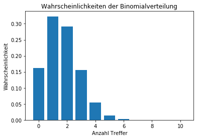

```python
%matplotlib inline
import pandas as pd
from scipy.stats import binom
import matplotlib.pyplot as plt

# Wir erstellen ein Dataframe (eine Tabelle) mit 2 Spalten:
# den x-Werten von 0 bis 10 und den zugehörigen p-Werten

ergebnisse = pd.DataFrame({"x":[0,1,2,3,4,5,6,7,8,9,10],
                          "y":binom.pmf([0,1,2,3,4,5,6,7,8,9,10],10,1/6)})

plt.bar(ergebnisse.x, ergebnisse.y)
plt.title("Wahrscheinlichkeiten der Binomialverteilung")
plt.xlabel("Anzahl Treffer")
plt.ylabel("Wahrscheinlichkeit")
plt.show()
```

**Beispiel 2:** Kumulierte Häufigkeit

Wie hoch ist die Wahrscheinlichkeit, dass beim 10-maligen Würfeln 1, 2 oder 3 Mal die 6 gewürfelt wird? Dazu müssen die Einzelwahrscheinlichkeiten für X=1, X=2 und X=3 addiert werden.

\begin{eqnarray*} = {10\choose 1} \cdot \left( \frac{1}{6}\right)^{1} \cdot \left(\frac{5}{6}\right)^{9} + {10\choose 2} \cdot \left( \frac{1}{6}\right)^{2} \cdot \left(\frac{5}{6}\right)^{8} + {10\choose 3} \cdot \left( \frac{1}{6}\right)^{3} \cdot \left(\frac{5}{6}\right)^{7} \\ = 0,323 + 0,291 + 0,155 \\ = \underline{0,769} \end{eqnarray*}

Die Aufgabe lässt sich mit Python wie folgt lösen:

```python
from scipy.stats import binom

binom.pmf([1,2,3], 10, 1/6).sum()
```

```
0.768766574555666
```

Mit Hilfe der Funktion *cdf* kann auch die kummulierte Wahrscheinlichkeit (von 0 .. k) berechnet werden, müssen dann aber die Wahrscheinlichkeit für k=0 wieder abziehen!

```python
binom.cdf(3, 10, 1/6) - binom.pmf(0,10,1/6)
```

```
0.7687665745556657
```

**Übung:** Aus einer Urne mit (theoretisch unendlich) vielen roten und blauen Kugeln werden 20 Kugeln gezogen. Nach jedem Ziehen wird die Kugel wieder zurückgelegt.

Wie groß ist die Wahrscheinlichkeit, dass 8 dieser Kugeln blau sind, wenn die Wahrscheinlichkeit, eine blaue Kugel zu ziehen, 35% beträgt?

Geben Sie den Python-Code, der die gesuchte Wahrscheinlichkeit ermittelt, in folgende Zeile ein:

```python
 # Hier den Code eingeben!
```

**Übung:** Wie groß ist die Wahrscheinlichkeit, *höchstens* 8 blaue Kugeln zu ziehen? (Ergebnis: 0.762)

Geben Sie auch hier wieder den gesuchten Python-Code ein:

```python
# Hier den Code eingeben!
```

### Normalverteilung

Die wohl wichtigste Verteilung, siehe auch "Zentraler Grenzwertsatz (ZGW)"

Merkmale:

- Typ: Stetige Verteilung
- Bekannt auch als "Gaußkurve" oder auch "Glockenkurve"
- Beispiele: Unendlich viele ("Schweizer Taschenmesser der Statistik")

Der *Zentrale Grenzwertsatz* besagt, dass die Stichprobenverteilung der Mittelwerte asymptotisch normalverteilt sein wird, unabhängig von der Form der zugrunde liegenden Verteilung der Daten, vorausgesetzt die Daten sind unabhängig und identisch verteilt. Häufig wird die Normalverteilung auch dazu verwendet, die Binomialverteilung einfacher zu berechnen. Dazu muss die Laplace-Bedingung erfüllt sein: Die Standardabweichung $\sigma$ muss mindestens 3 ergeben:

$ \sigma = \sqrt{n \cdot p \cdot (1-p)} > 3 $

Funktion der Normalverteilung:

$ f(x) = \frac {1}{\sigma\sqrt{2\pi}} e^{-\frac {1}{2} \left(\frac{x-\mu}{\sigma}\right)^2} $

Dabei gilt:

- $\sigma$: Standardabweichung der Grundgesamtheit
- $\mu$: Erwartungswert der Grundgesamtheit

Wir erstellen mit folgendem Code einen Plot, der die bekannte Glockenkurve zeigt:

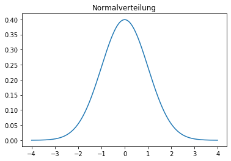

```python
import numpy as np
from scipy.stats import norm
import matplotlib.pyplot as plt

x = np.arange(-4,4,.01)
y = norm.pdf(x)

plt.plot(x,y)
plt.title("Normalverteilung")
plt.show()
```

### Standardnormalverteilung

Bei der Standardnormalverteilung beträgt die Standardabweichung $\sigma$ immer eins, der Erwartungswert $\mu$ immer 0. In der Praxis wird häufig die Standardnormalverteilung verwendet. Dazu müssen alle x-Werte in standardisierte z-Werte umgewandelt werden:

$ z_{i} = \frac{x_{i}-\mu}{\sigma} $

**Beispiel:** Die Körpergröße sei normalverteilt. Wie groß ist die Wahrscheinlichkeit, dass ein zufällig ausgewählter Mann zwischen 70 und 72 inches groß ist?

Wir lösen diese Aufgabe mit Python, und zwar auf 2 Wegen:

- Zuerst die Schritt-für-Schritt-Lösung (wie in der Schule ;-)
- Dann mit einem einzigen Python-Befehl!

```python
from scipy.stats import stats
# Schritt-für-Schritt - Lösung

# Wir ermitteln den Mittelwert der Körpergrößen der Männer
x_quer = daten[daten.sex=="Male"].height.mean()
print("Mittelwert: " , x_quer)

# Wir ermitteln die Standardabweichung der Körpergrößen der Männer
s = daten[daten.sex=="Male"].height.std()
print("Standardabweichung" , s)

# Wier bestimmen die Z-Werte für die beiden Grenzen
z_links = (70-x_quer) / s
z_rechts = (72-x_quer) / s
print("z links:", z_links, ", z rechts:", z_rechts)

# Wir schauen in eine Tabelle für Normalverteilungen (siehe Internet oder auch im Skript).
# Die gesuchte Wahrscheinlichkeit ist die Fläche unter der Kurve zwischen den beiden Z-Werten.

# Für z.links finden wir einen Wert von 0,5753, für z.rechts einen Wert von 0,7704
# Somit ergibt sich die Lösung

p = 0.7704 - 0.5753
print("Ergebnis:" , p)

# Nun die Lösung mit Hilfe der Python-Funktion dnorm:
norm.cdf(72, x_quer, s) - norm.cdf(70, x_quer, s)
```

```
Mittelwert:  69.31475494143558
Standardabweichung 3.6110236746672952
z links: 0.1897647648703258 , z rechts: 0.7436243294117496
Ergebnis: 0.19509999999999994
```

```
0.19619484376445206
```

Das folgende Diagramm visualisiert diese Aufgabe. Der rot markierte Bereich unter der Kurve entspricht der gesuchten Wahrscheinlichkeit:

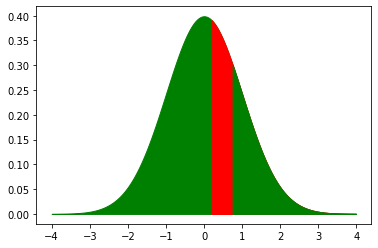

```python
import numpy as np
import matplotlib.pyplot as plt
from scipy.stats import norm
x = np.arange(-4,4,.01)
y = norm.pdf(x)
plt.fill_between(x,y,0, color="green")
plt.fill_between(x,y,0, x>0.19 ,  color="red")
plt.fill_between(x,y,0, x>0.74 ,  color="green")
plt.show()
```

## Hypothesentest und p-Wert

*Beispiel:* Bei einem neuen Medikament wird behauptet, dass eine Nebenwirkung mit einer Wahrscheinlichkeit von bis zu 10% auftritt. Diese Information soll auf den Beipackzettel des Medikaments gedruckt werden. Bei einer klinischen Studie wurde bei 10 von 50 Patienten diese Nebenwirkungen festgestellt. Ist die Angabe auf dem Beipackzettel haltbar?

Als Signifikanzniveau soll 5% verwendet werden.

$H_0$ lautet: P(Nebenwirkung) <= 10%

$H_1$ lautet: P(Nebenwirkung) > 10%

Falls $H_0$ richtig ist, beträgt die Wahrscheinlichkeit, dass von 50 Patienten bei 10 ODER MEHR Patienten Nebenwirkungen auftreten:

```python
import numpy as np
from scipy.stats import binom_test

p = binom_test(10, 50, 0.1, alternative="greater")
print(p)
```

```
0.024537935704591503
```

Die folgende Grafik zeigt die Binomialverteilung für die Anzahl der Patienten mit Nebenwirkung. Da ab ca. 15 Patienten die Wahrscheinlichkeit fast 0 ist, werden nur die ersten 20 Wahrscheinlichkeiten angezeigt.

```
<BarContainer object of 9 artists>
```

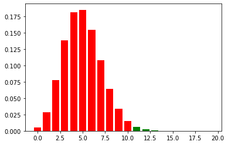

```python
#wahrscheinlichkeiten <- data.frame(x=0:20, p=dbinom(0:20, 50, .1))

#bp <- barplot(wahrscheinlichkeiten$p, xlim=c(0,20), col=c(rep("blue",10), rep("red",10)),
#        names.arg = wahrscheinlichkeiten$x,
#        main = "Wahrscheinlichkeitsverteilung",
#        xlab = "Anzahl Patienten mit Nebenwirkungen",
#        ylab = "Wahrscheinlichkeit der Nebenwirkung",
#        ylim=c(0,.2))
#
#text(bp, wahrscheinlichkeiten$p, labels=round(wahrscheinlichkeiten$p*1000)/1000,
#     col="red", pos=3, cex=.8)

import numpy as np
import pandas as pd
import matplotlib.pyplot as plt
from scipy.stats import binom
x = np.arange(20)
p = binom.pmf(x, 50, .1)

plt.bar(x[0:11],p[0:11], color="r")
plt.bar(x[11:],p[11:], color="g")
```

Allgemein formuliert: Der p-Wert gibt die Wahrscheinlichkeit an, dass unter der Annahme, dass die 0-Hypothese gültig ist, ein Ergebnis wie das ermittelte oder noch extremer auftritt.